# act_report

## Report: act_report

### Introduction¶

Real-world data rarely comes clean. Using Python and its libraries, I proceeded to gather data from a variety of sources and in a variety of formats, assess its quality and tidiness, then clean it. This process is known as data wrangling. I proceeded to document my wrangling efforts in a Jupyter Notebook, plus showcase them through analyses and visualizations using Python (and its libraries).

The dataset that I wrangled (and analyzing and visualizing) is the tweet archive of Twitter user @dog_rates, also known as WeRateDogs. WeRateDogs is a Twitter account that rates people's dogs with a humorous comment about the dog. These ratings almost always have a denominator of 10. The numerators, though? Almost always greater than 10. 11/10, 12/10, 13/10, etc. Why? Because "they're good dogs Brent." WeRateDogs has over 4 million followers and has received international media coverage.

### Data Exploration

Exploring the dataset was very insightful as it gave a lot of information pertaining the relationship with how the followers of the twitter account interacted with the content by the account.

[figure not shown]

#### Insight garnered

1. Pictures of dogs within the doggo and puppo stage ilicit the most average retweets among those engaging the we rate dogs twitter account.
1. analyzing the favorite count or the likes cout also showed that the dogs pictures within the doggo and puppo ages were the most liked on an average
1. while analyzing the relationship between the dog stages and the rating by the we rate dogs twitter accounts showed that dogs within the doggo and puppo ages received the most average ratings by the account.

### Data Visualization

From the visualization it is evident that there's a positive correlelation between the retweet count and favorite count, which is understandable as common in twitter most engagers typically like and subsequently retweets as a way to share the content to others thus it is a kind symbiotic relationship between the favorite count and retweet counts.

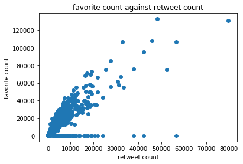